# Project: Wrangling and Analyze Data

|  | tweet_id | in_reply_to_status_id | in_reply_to_user_id | timestamp | source | text | retweeted_status_id | retweeted_status_user_id | retweeted_status_timestamp | expanded_urls | rating_numerator | rating_denominator | name | doggo | floofer | pupper | puppo | retweet_count | favorite_count | jpg_url | img_num | p1 | p1_conf | p1_dog | p2 | p2_conf | p2_dog | p3 | p3_conf | … |
| --- | --- | --- | --- | --- | --- | --- | --- | --- | --- | --- | --- | --- | --- | --- | --- | --- | --- | --- | --- | --- | --- | --- | --- | --- | --- | --- | --- | --- | --- | --- |
| 50 | 881536004380872706 | NaN | NaN | 2017-07-02 15:32:16 +0000 | <a href="http://twitter.com/download/iphone" rel="nofollow">Twitter for iPhone</a> | Here is a pupper approaching maximum borkdrive. Zooming at never before seen speeds. 14/10 paw-inspiring af \n(IG: puffie_the_chow) https://t.co/ghXBIIeQZF | NaN | NaN | NaN | https://twitter.com/dog_rates/status/881536004380872706/video/1 | 14 | 10 | a | None | None | pupper | None | 16570 | 50199 | https://pbs.twimg.com/ext_tw_video_thumb/881535971568889856/pu/img/9bawiZ--8FKywTkz.jpg | 1 | Samoyed | 0.281463 | True | Angora | 0.272066 | False | Persian_cat | 0.114854 | … |
| 524 | 792913359805018113 | NaN | NaN | 2016-10-31 02:17:31 +0000 | <a href="http://twitter.com/download/iphone" rel="nofollow">Twitter for iPhone</a> | Here is a perfect example of someone who has their priorities in order. 13/10 for both owner and Forrest https://t.co/LRyMrU7Wfq | NaN | NaN | NaN | https://twitter.com/dog_rates/status/792913359805018113/photo/1,https://twitter.com/dog_rates/status/792913359805018113/photo/1,https://twitter.com/dog_rates/status/792913359805018113/photo/1,https://… | 13 | 10 | a | None | None | None | None | 4715 | 16063 | https://pbs.twimg.com/media/CwD-eCLWIAA6v0B.jpg | 4 | web_site | 0.226716 | False | lighter | 0.081941 | False | switch | 0.039009 | … |
| 647 | 772581559778025472 | NaN | NaN | 2016-09-04 23:46:12 +0000 | <a href="http://twitter.com/download/iphone" rel="nofollow">Twitter for iPhone</a> | Guys this is getting so out of hand. We only rate dogs. This is a Galapagos Speed Panda. Pls only send dogs... 10/10 https://t.co/8lpAGaZRFn | NaN | NaN | NaN | https://twitter.com/dog_rates/status/772581559778025472/photo/1,https://twitter.com/dog_rates/status/772581559778025472/photo/1,https://twitter.com/dog_rates/status/772581559778025472/photo/1 | 10 | 10 | a | None | None | None | None | 1968 | 7192 | https://pbs.twimg.com/media/CrjC0JAWAAAjz6n.jpg | 3 | Newfoundland | 0.574345 | True | Border_collie | 0.128352 | True | Saint_Bernard | 0.059476 | … |
| 822 | 747885874273214464 | NaN | NaN | 2016-06-28 20:14:22 +0000 | <a href="http://twitter.com/download/iphone" rel="nofollow">Twitter for iPhone</a> | This is a mighty rare blue-tailed hammer sherk. Human almost lost a limb trying to take these. Be careful guys. 8/10 https://t.co/TGenMeXreW | NaN | NaN | NaN | https://twitter.com/dog_rates/status/747885874273214464/photo/1,https://twitter.com/dog_rates/status/747885874273214464/photo/1 | 8 | 10 | a | None | None | None | None | 1116 | 3243 | https://pbs.twimg.com/media/CmEGMSvUYAAl3ZM.jpg | 1 | kuvasz | 0.408450 | True | Samoyed | 0.141330 | True | pug | 0.083018 | … |
| 824 | 747816857231626240 | NaN | NaN | 2016-06-28 15:40:07 +0000 | <a href="http://twitter.com/download/iphone" rel="nofollow">Twitter for iPhone</a> | Viewer discretion is advised. This is a terrible attack in progress. Not even in water (tragic af). 4/10 bad sherk https://t.co/L3U0j14N5R | NaN | NaN | NaN | https://twitter.com/dog_rates/status/747816857231626240/photo/1 | 4 | 10 | a | None | None | None | None | 1316 | 5346 | https://pbs.twimg.com/media/CmDHdCoWkAACTB4.jpg | 1 | Pembroke | 0.768923 | True | Chihuahua | 0.029053 | True | Shetland_sheepdog | 0.029035 | … |
| 833 | 746872823977771008 | NaN | NaN | 2016-06-26 01:08:52 +0000 | <a href="http://twitter.com/download/iphone" rel="nofollow">Twitter for iPhone</a> | This is a carrot. We only rate dogs. Please only send in dogs. You all really should know this by now ...11/10 https://t.co/9e48aPrBm2 | NaN | NaN | NaN | https://twitter.com/dog_rates/status/746872823977771008/photo/1,https://twitter.com/dog_rates/status/746872823977771008/photo/1 | 11 | 10 | a | None | None | None | None | 2429 | 6593 | https://pbs.twimg.com/media/Cl1s1p7WMAA44Vk.jpg | 1 | Pembroke | 0.540201 | True | beagle | 0.207835 | True | Italian_greyhound | 0.043565 | … |
| 859 | 743222593470234624 | NaN | NaN | 2016-06-15 23:24:09 +0000 | <a href="http://twitter.com/download/iphone" rel="nofollow">Twitter for iPhone</a> | This is a very rare Great Alaskan Bush Pupper. Hard to stumble upon without spooking. 12/10 would pet passionately https://t.co/xOBKCdpzaa | NaN | NaN | NaN | https://twitter.com/dog_rates/status/743222593470234624/photo/1 | 12 | 10 | a | None | None | pupper | None | 2164 | 6792 | https://pbs.twimg.com/media/ClB09z0WYAAA1jz.jpg | 1 | kuvasz | 0.350629 | True | soft-coated_wheaten_terrier | 0.182782 | True | golden_retriever | 0.087662 | … |
| 995 | 717537687239008257 | NaN | NaN | 2016-04-06 02:21:30 +0000 | <a href="http://twitter.com/download/iphone" rel="nofollow">Twitter for iPhone</a> | People please. This is a Deadly Mediterranean Plop T-Rex. We only rate dogs. Only send in dogs. Thanks you... 11/10 https://t.co/2ATDsgHD4n | NaN | NaN | NaN | https://twitter.com/dog_rates/status/717537687239008257/photo/1 | 11 | 10 | a | None | None | None | None | 2069 | 6281 | https://pbs.twimg.com/media/CfU0t75W4AAUo9V.jpg | 1 | golden_retriever | 0.779356 | True | Labrador_retriever | 0.052511 | True | kuvasz | 0.049811 | … |
| 1005 | 715733265223708672 | NaN | NaN | 2016-04-01 02:51:22 +0000 | <a href="http://twitter.com/download/iphone" rel="nofollow">Twitter for iPhone</a> | This is a taco. We only rate dogs. Please only send in dogs. Dogs are what we rate. Not tacos. Thank you... 10/10 https://t.co/cxl6xGY8B9 | NaN | NaN | NaN | https://twitter.com/dog_rates/status/715733265223708672/photo/1 | 10 | 10 | a | None | None | None | None | 1920 | 5093 | https://pbs.twimg.com/media/Ce7LlUeUUAEQkQl.jpg | 1 | Dandie_Dinmont | 0.740229 | True | miniature_poodle | 0.081915 | True | toy_poodle | 0.063748 | … |
| 1122 | 704859558691414016 | NaN | NaN | 2016-03-02 02:43:09 +0000 | <a href="http://twitter.com/download/iphone" rel="nofollow">Twitter for iPhone</a> | Here is a heartbreaking scene of an incredible pupper being laid to rest. 10/10 RIP pupper https://t.co/81mvJ0rGRu | NaN | NaN | NaN | https://twitter.com/dog_rates/status/704859558691414016/photo/1 | 10 | 10 | a | None | None | pupper | None | 612 | 2462 | https://pbs.twimg.com/media/CcgqBNVW8AE76lv.jpg | 1 | pug | 0.284428 | True | teddy | 0.156339 | False | mitten | 0.138915 | … |
| 1131 | 704054845121142784 | NaN | NaN | 2016-02-28 21:25:30 +0000 | <a href="http://twitter.com/download/iphone" rel="nofollow">Twitter for iPhone</a> | Here is a whole flock of puppers. 60/50 I'll take the lot https://t.co/9dpcw6MdWa | NaN | NaN | NaN | https://twitter.com/dog_rates/status/704054845121142784/photo/1 | 60 | 50 | a | None | None | None | None | 1028 | 3201 | https://pbs.twimg.com/media/CcVOJEcXEAM0FHL.jpg | 1 | Great_Pyrenees | 0.667939 | True | kuvasz | 0.228764 | True | golden_retriever | 0.043885 | … |
| 1141 | 703079050210877440 | NaN | NaN | 2016-02-26 04:48:02 +0000 | <a href="http://twitter.com/download/iphone" rel="nofollow">Twitter for iPhone</a> | This is a Butternut Cumberfloof. It's not windy they just look like that. 11/10 back at it again with the red socks https://t.co/hMjzhdUHaW | NaN | NaN | NaN | https://twitter.com/dog_rates/status/703079050210877440/photo/1,https://twitter.com/dog_rates/status/703079050210877440/photo/1 | 11 | 10 | a | None | None | None | None | 3494 | 8064 | https://pbs.twimg.com/media/CcHWqQCW8AEb0ZH.jpg | 2 | Pembroke | 0.778503 | True | Shetland_sheepdog | 0.093834 | True | Cardigan | 0.060296 | … |
| 1147 | 702539513671897089 | NaN | NaN | 2016-02-24 17:04:07 +0000 | <a href="http://twitter.com/download/iphone" rel="nofollow">Twitter for iPhone</a> | This is a Wild Tuscan Poofwiggle. Careful not to startle. Rare tongue slip. One eye magical. 12/10 would def pet https://t.co/4EnShAQjv6 | NaN | NaN | NaN | https://twitter.com/dog_rates/status/702539513671897089/photo/1,https://twitter.com/dog_rates/status/702539513671897089/photo/1,https://twitter.com/dog_rates/status/702539513671897089/photo/1 | 12 | 10 | a | None | None | None | None | 1091 | 3134 | https://pbs.twimg.com/media/Cb_r8qTUsAASgdF.jpg | 3 | Pomeranian | 0.714367 | True | Shih-Tzu | 0.040574 | True | silky_terrier | 0.032510 | … |
| 1159 | 700864154249383937 | NaN | NaN | 2016-02-20 02:06:50 +0000 | <a href="http://twitter.com/download/iphone" rel="nofollow">Twitter for iPhone</a> | "Pupper is a present to world. Here is a bow for pupper." 12/10 precious as hell https://t.co/ItSsE92gCW | NaN | NaN | NaN | https://twitter.com/dog_rates/status/700864154249383937/photo/1 | 12 | 10 | a | None | None | pupper | None | 685 | 2828 | https://pbs.twimg.com/media/Cbn4OqKWwAADGWt.jpg | 1 | kuvasz | 0.805857 | True | Great_Pyrenees | 0.187272 | True | Samoyed | 0.003491 | … |
| 1262 | 692187005137076224 | NaN | NaN | 2016-01-27 03:26:56 +0000 | <a href="http://twitter.com/download/iphone" rel="nofollow">Twitter for iPhone</a> | This is a rare Arctic Wubberfloof. Unamused by the happenings. No longer has the appetites. 12/10 would totally hug https://t.co/krvbacIX0N | NaN | NaN | NaN | https://twitter.com/dog_rates/status/692187005137076224/photo/1,https://twitter.com/dog_rates/status/692187005137076224/photo/1,https://twitter.com/dog_rates/status/692187005137076224/photo/1 | 12 | 10 | a | None | None | None | None | 929 | 2768 | https://pbs.twimg.com/media/CZskaEIWIAUeTr5.jpg | 2 | Siberian_husky | 0.810592 | True | malamute | 0.119745 | True | Eskimo_dog | 0.029265 | … |
| 1475 | 679530280114372609 | NaN | NaN | 2015-12-23 05:13:38 +0000 | <a href="http://twitter.com/download/iphone" rel="nofollow">Twitter for iPhone</a> | Guys this really needs to stop. We've been over this way too many times. This is a giraffe. We only rate dogs.. 7/10 https://t.co/yavgkHYPOC | NaN | NaN | NaN | https://twitter.com/dog_rates/status/679530280114372609/photo/1 | 7 | 10 | a | None | None | None | None | 2347 | 5208 | https://pbs.twimg.com/media/CW4tL1vWcAIw1dw.jpg | 1 | dalmatian | 0.750256 | True | jaguar | 0.169007 | False | zebra | 0.006481 | … |
| 1518 | 677644091929329666 | NaN | NaN | 2015-12-18 00:18:36 +0000 | <a href="http://twitter.com/download/iphone" rel="nofollow">Twitter for iPhone</a> | This is a dog swinging. I really enjoyed it so I hope you all do as well. 11/10 https://t.co/Ozo9KHTRND | NaN | NaN | NaN | https://twitter.com/dog_rates/status/677644091929329666/video/1 | 11 | 10 | a | None | None | None | None | 886 | 2040 | https://pbs.twimg.com/ext_tw_video_thumb/677644010865999872/pu/img/zVHEMYnJKzq1SauT.jpg | 1 | Chihuahua | 0.626236 | True | Italian_greyhound | 0.128483 | True | swing | 0.059840 | … |
| 1580 | 675706639471788032 | NaN | NaN | 2015-12-12 15:59:51 +0000 | <a href="http://twitter.com/download/iphone" rel="nofollow">Twitter for iPhone</a> | This is a Sizzlin Menorah spaniel from Brooklyn named Wylie. Lovable eyes. Chiller as hell. 10/10 and I'm out.. poof https://t.co/7E0AiJXPmI | NaN | NaN | NaN | https://twitter.com/dog_rates/status/675706639471788032/photo/1 | 10 | 10 | a | None | None | None | None | 106 | 693 | https://pbs.twimg.com/media/CWCXj35VEAIFvtk.jpg | 1 | English_springer | 0.990300 | True | Welsh_springer_spaniel | 0.002080 | True | cocker_spaniel | 0.002014 | … |
| 1581 | 675534494439489536 | NaN | NaN | 2015-12-12 04:35:48 +0000 | <a href="http://twitter.com/download/iphone" rel="nofollow">Twitter for iPhone</a> | Seriously guys?! Only send in dogs. I only rate dogs. This is a baby black bear... 11/10 https://t.co/H7kpabTfLj | NaN | NaN | NaN | https://twitter.com/dog_rates/status/675534494439489536/photo/1 | 11 | 10 | a | None | None | None | None | 470 | 1953 | https://pbs.twimg.com/media/CV_7CV6XIAEV05u.jpg | 1 | chow | 0.749368 | True | schipperke | 0.133738 | True | Newfoundland | 0.049914 | … |
| 1604 | 675109292475830276 | NaN | NaN | 2015-12-11 00:26:12 +0000 | <a href="http://twitter.com/download/iphone" rel="nofollow">Twitter for iPhone</a> | C'mon guys. We've been over this. We only rate dogs. This is a cow. Please only submit dogs. Thank you...... 9/10 https://t.co/WjcELNEqN2 | NaN | NaN | NaN | https://twitter.com/dog_rates/status/675109292475830276/photo/1 | 9 | 10 | a | None | None | None | None | 1259 | 3006 | https://pbs.twimg.com/media/CV54UQTXAAAGf-j.jpg | 1 | dalmatian | 0.989519 | True | English_setter | 0.005258 | True | German_short-haired_pointer | 0.001443 | … |
| 1605 | 675047298674663426 | NaN | NaN | 2015-12-10 20:19:52 +0000 | <a href="http://twitter.com/download/iphone" rel="nofollow">Twitter for iPhone</a> | This is a fluffy albino Bacardi Columbia mix. Excellent at the tweets. 11/10 would hug gently https://t.co/diboDRUuEI | NaN | NaN | NaN | https://twitter.com/dog_rates/status/675047298674663426/photo/1 | 11 | 10 | a | None | None | None | None | 366 | 1141 | https://pbs.twimg.com/media/CV4_8FgXAAQOj4S.jpg | 1 | Samoyed | 0.978007 | True | chow | 0.007121 | True | Pomeranian | 0.006398 | … |
| 1646 | 674082852460433408 | NaN | NaN | 2015-12-08 04:27:30 +0000 | <a href="http://twitter.com/download/iphone" rel="nofollow">Twitter for iPhone</a> | This is a Sagitariot Baklava mix. Loves her new hat. 11/10 radiant pup https://t.co/Bko5kFJYUU | NaN | NaN | NaN | https://twitter.com/dog_rates/status/674082852460433408/photo/1 | 11 | 10 | a | None | None | None | None | 186 | 804 | https://pbs.twimg.com/media/CVrSxy7WsAAFD2F.jpg | 1 | Pomeranian | 0.666957 | True | Shetland_sheepdog | 0.028019 | True | ski_mask | 0.020683 | … |
| 1663 | 673715861853720576 | NaN | NaN | 2015-12-07 04:09:13 +0000 | <a href="http://twitter.com/download/iphone" rel="nofollow">Twitter for iPhone</a> | This is a heavily opinionated dog. Loves walls. Nobody knows how the hair works. Always ready for a kiss. 4/10 https://t.co/dFiaKZ9cDl | NaN | NaN | NaN | https://twitter.com/dog_rates/status/673715861853720576/photo/1 | 4 | 10 | a | None | None | None | None | 2303 | 3815 | https://pbs.twimg.com/media/CVmE_fAWIAAlDhU.jpg | 1 | suit | 0.404115 | False | bow_tie | 0.294683 | False | Windsor_tie | 0.132701 | … |
| 1677 | 673636718965334016 | NaN | NaN | 2015-12-06 22:54:44 +0000 | <a href="http://twitter.com/download/iphone" rel="nofollow">Twitter for iPhone</a> | This is a Lofted Aphrodisiac Terrier named Kip. Big fan of bed n breakfasts. Fits perfectly. 10/10 would pet firmly https://t.co/gKlLpNzIl3 | NaN | NaN | NaN | https://twitter.com/dog_rates/status/673636718965334016/photo/1 | 10 | 10 | a | None | None | None | None | 404 | 1194 | https://pbs.twimg.com/media/CVk9ApFWUAA-S1s.jpg | 1 | wombat | 0.880257 | False | corn | 0.019421 | False | pug | 0.019044 | … |
| 1716 | 672604026190569472 | NaN | NaN | 2015-12-04 02:31:10 +0000 | <a href="http://twitter.com/download/iphone" rel="nofollow">Twitter for iPhone</a> | This is a baby Rand Paul. Curls for days. 11/10 would cuddle the hell out of https://t.co/xHXNaPAYRe | NaN | NaN | NaN | https://twitter.com/dog_rates/status/672604026190569472/photo/1 | 11 | 10 | a | None | None | None | None | 445 | 1188 | https://pbs.twimg.com/media/CVWRyylWIAAMltv.jpg | 1 | toy_poodle | 0.820158 | True | miniature_poodle | 0.178404 | True | toilet_tissue | 0.000291 | … |
| 1756 | 671743150407421952 | NaN | NaN | 2015-12-01 17:30:22 +0000 | <a href="http://twitter.com/download/iphone" rel="nofollow">Twitter for iPhone</a> | This is a Tuscaloosa Alcatraz named Jacob (Yacōb). Loves to sit in swing. Stellar tongue. 11/10 look at his feet https://t.co/2IslQ8ZSc7 | NaN | NaN | NaN | https://twitter.com/dog_rates/status/671743150407421952/photo/1 | 11 | 10 | a | None | None | None | None | 248 | 779 | https://pbs.twimg.com/media/CVKC1IfWIAAsQks.jpg | 1 | toy_poodle | 0.419427 | True | miniature_poodle | 0.237067 | True | swing | 0.104193 | … |
| 1787 | 671147085991960577 | NaN | NaN | 2015-11-30 02:01:49 +0000 | <a href="http://twitter.com/download/iphone" rel="nofollow">Twitter for iPhone</a> | This is a Helvetica Listerine named Rufus. This time Rufus will be ready for the UPS guy. He'll never expect it 9/10 https://t.co/34OhVhMkVr | NaN | NaN | NaN | https://twitter.com/dog_rates/status/671147085991960577/photo/1 | 9 | 10 | a | None | None | None | None | 254 | 713 | https://pbs.twimg.com/media/CVBktzQXAAAPpUA.jpg | 1 | Yorkshire_terrier | 0.467202 | True | cairn | 0.440122 | True | silky_terrier | 0.058690 | … |
| 1837 | 670427002554466305 | NaN | NaN | 2015-11-28 02:20:27 +0000 | <a href="http://twitter.com/download/iphone" rel="nofollow">Twitter for iPhone</a> | This is a Deciduous Trimester mix named Spork. Only 1 ear works. No seat belt. Incredibly reckless. 9/10 still cute https://t.co/CtuJoLHiDo | NaN | NaN | NaN | https://twitter.com/dog_rates/status/670427002554466305/photo/1 | 9 | 10 | a | None | None | None | None | 179 | 551 | https://pbs.twimg.com/media/CU3VzVwWwAAAsst.jpg | 1 | seat_belt | 0.952258 | False | toy_terrier | 0.038872 | True | beagle | 0.003226 | … |
| 1846 | 670361874861563904 | NaN | NaN | 2015-11-27 22:01:40 +0000 | <a href="http://twitter.com/download/iphone" rel="nofollow">Twitter for iPhone</a> | This is a Rich Mahogany Seltzer named Cherokee. Just got destroyed by a snowball. Isn't very happy about it. 9/10 https://t.co/98ZBi6o4dj | NaN | NaN | NaN | https://twitter.com/dog_rates/status/670361874861563904/photo/1 | 9 | 10 | a | None | None | None | None | 71 | 344 | https://pbs.twimg.com/media/CU2akCQWsAIbaOV.jpg | 1 | platypus | 0.974075 | False | spotted_salamander | 0.011068 | False | bison | 0.003897 | … |
| 1849 | 670303360680108032 | NaN | NaN | 2015-11-27 18:09:09 +0000 | <a href="http://twitter.com/download/iphone" rel="nofollow">Twitter for iPhone</a> | This is a Speckled Cauliflower Yosemite named Hemry. He's terrified of intruder dog. Not one bit comfortable. 9/10 https://t.co/yV3Qgjh8iN | NaN | NaN | NaN | https://twitter.com/dog_rates/status/670303360680108032/photo/1 | 9 | 10 | a | None | None | None | None | 151 | 452 | https://pbs.twimg.com/media/CU1lWFaVAAAl0HG.jpg | 1 | Shetland_sheepdog | 0.380278 | True | Cardigan | 0.342806 | True | guinea_pig | 0.156249 | … |
| 1867 | 669923323644657664 | NaN | NaN | 2015-11-26 16:59:01 +0000 | <a href="http://twitter.com/download/iphone" rel="nofollow">Twitter for iPhone</a> | This is a spotted Lipitor Rumpelstiltskin named Alphred. He can't wait for the Turkey. 10/10 would pet really well https://t.co/6GUGO7azNX | NaN | NaN | NaN | https://twitter.com/dog_rates/status/669923323644657664/photo/1 | 10 | 10 | a | None | None | None | None | 64 | 250 | https://pbs.twimg.com/media/CUwLtPeU8AAfAb2.jpg | 1 | car_mirror | 0.343063 | False | seat_belt | 0.110289 | False | wing | 0.080148 | … |
| 1873 | 669661792646373376 | NaN | NaN | 2015-11-25 23:39:47 +0000 | <a href="http://twitter.com/download/iphone" rel="nofollow">Twitter for iPhone</a> | This is a brave dog. Excellent free climber. Trying to get closer to God. Not very loyal though. Doesn't bark. 5/10 https://t.co/ODnILTr4QM | NaN | NaN | NaN | https://twitter.com/dog_rates/status/669661792646373376/photo/1 | 5 | 10 | a | None | None | None | None | 482 | 860 | https://pbs.twimg.com/media/CUsd2TfWwAAmdjb.jpg | 1 | weasel | 0.262802 | False | Siamese_cat | 0.148263 | False | hamster | 0.116374 | … |
| 1881 | 669564461267722241 | NaN | NaN | 2015-11-25 17:13:02 +0000 | <a href="http://twitter.com/download/iphone" rel="nofollow">Twitter for iPhone</a> | This is a Coriander Baton Rouge named Alfredo. Loves to cuddle with smaller well-dressed dog. 10/10 would hug lots https://t.co/eCRdwouKCl | NaN | NaN | NaN | https://twitter.com/dog_rates/status/669564461267722241/photo/1 | 10 | 10 | a | None | None | None | None | 133 | 413 | https://pbs.twimg.com/media/CUrFUvDVAAA9H-F.jpg | 1 | toy_poodle | 0.623685 | True | miniature_poodle | 0.259920 | True | standard_poodle | 0.082530 | … |
| 1910 | 668955713004314625 | NaN | NaN | 2015-11-24 00:54:05 +0000 | <a href="http://twitter.com/download/iphone" rel="nofollow">Twitter for iPhone</a> | This is a Slovakian Helter Skelter Feta named Leroi. Likes to skip on roofs. Good traction. Much balance. 10/10 wow! https://t.co/Dmy2mY2Qj5 | NaN | NaN | NaN | https://twitter.com/dog_rates/status/668955713004314625/photo/1 | 10 | 10 | a | None | None | None | None | 77 | 300 | https://pbs.twimg.com/media/CUibq3uVAAAup_O.jpg | 1 | cocker_spaniel | 0.367492 | True | Lakeland_terrier | 0.272621 | True | soft-coated_wheaten_terrier | 0.067006 | … |
| 1917 | 668815180734689280 | NaN | NaN | 2015-11-23 15:35:39 +0000 | <a href="http://twitter.com/download/iphone" rel="nofollow">Twitter for iPhone</a> | This is a wild Toblerone from Papua New Guinea. Mouth always open. Addicted to hay. Acts blind. 7/10 handsome dog https://t.co/IGmVbz07tZ | NaN | NaN | NaN | https://twitter.com/dog_rates/status/668815180734689280/photo/1 | 7 | 10 | a | None | None | None | None | 291 | 610 | https://pbs.twimg.com/media/CUgb21RXIAAlff7.jpg | 1 | redbone | 0.461172 | True | Italian_greyhound | 0.270733 | True | miniature_pinscher | 0.109752 | … |
| 1930 | 668614819948453888 | NaN | NaN | 2015-11-23 02:19:29 +0000 | <a href="http://twitter.com/download/iphone" rel="nofollow">Twitter for iPhone</a> | Here is a horned dog. Much grace. Can jump over moons (dam!). Paws not soft. Bad at barking. 7/10 can still pet tho https://t.co/2Su7gmsnZm | NaN | NaN | NaN | https://twitter.com/dog_rates/status/668614819948453888/photo/1 | 7 | 10 | a | None | None | None | None | 341 | 654 | https://pbs.twimg.com/media/CUdloW8WEAAxB_Y.jpg | 1 | bustard | 0.380772 | False | pelican | 0.100554 | False | crane | 0.084713 | … |
| 1936 | 668507509523615744 | NaN | NaN | 2015-11-22 19:13:05 +0000 | <a href="http://twitter.com/download/iphone" rel="nofollow">Twitter for iPhone</a> | This is a Birmingham Quagmire named Chuk. Loves to relax and watch the game while sippin on that iced mocha. 10/10 https://t.co/HvNg9JWxFt | NaN | NaN | NaN | https://twitter.com/dog_rates/status/668507509523615744/photo/1 | 10 | 10 | a | None | None | None | None | 116 | 345 | https://pbs.twimg.com/media/CUcECBYWcAAzFRg.jpg | 1 | basenji | 0.055379 | True | Shetland_sheepdog | 0.054322 | True | whippet | 0.051913 | … |
| 1940 | 668466899341221888 | NaN | NaN | 2015-11-22 16:31:42 +0000 | <a href="http://twitter.com/download/iphone" rel="nofollow">Twitter for iPhone</a> | Here is a mother dog caring for her pups. Snazzy red mohawk. Doesn't wag tail. Pups look confused. Overall 4/10 https://t.co/YOHe6lf09m | NaN | NaN | NaN | https://twitter.com/dog_rates/status/668466899341221888/photo/1 | 4 | 10 | a | None | None | None | None | 560 | 936 | https://pbs.twimg.com/media/CUbfGbbWoAApZth.jpg | 1 | shopping_basket | 0.398361 | False | hamper | 0.363222 | False | bassinet | 0.084173 | … |
| 1953 | 668171859951755264 | NaN | NaN | 2015-11-21 20:59:20 +0000 | <a href="http://twitter.com/download/iphone" rel="nofollow">Twitter for iPhone</a> | This is a Trans Siberian Kellogg named Alfonso. Huge ass eyeballs. Actually Dobby from Harry Potter. 7/10 https://t.co/XpseHBlAAb | NaN | NaN | NaN | https://twitter.com/dog_rates/status/668171859951755264/photo/1 | 7 | 10 | a | None | None | None | None | 208 | 525 | https://pbs.twimg.com/media/CUXSwy8W4AA6uet.jpg | 1 | Chihuahua | 0.664834 | True | cowboy_boot | 0.060343 | False | giant_panda | 0.059838 | … |
| 1967 | 667861340749471744 | NaN | NaN | 2015-11-21 00:25:26 +0000 | <a href="http://twitter.com/download/iphone" rel="nofollow">Twitter for iPhone</a> | This is a Shotokon Macadamia mix named Cheryl. Sophisticated af. Looks like a disappointed librarian. Shh (lol) 9/10 https://t.co/J4GnJ5Swba | NaN | NaN | NaN | https://twitter.com/dog_rates/status/667861340749471744/photo/1 | 9 | 10 | a | None | None | None | None | 86 | 253 | https://pbs.twimg.com/media/CUS4WJ-UsAEJj10.jpg | 1 | malamute | 0.967275 | True | Siberian_husky | 0.016168 | True | Eskimo_dog | 0.011277 | … |
| 1973 | 667773195014021121 | NaN | NaN | 2015-11-20 18:35:10 +0000 | <a href="http://twitter.com" rel="nofollow">Twitter Web Client</a> | This is a rare Hungarian Pinot named Jessiga. She is either mid-stroke or got stuck in the washing machine. 8/10 https://t.co/ZU0i0KJyqD | NaN | NaN | NaN | https://twitter.com/dog_rates/status/667773195014021121/photo/1 | 8 | 10 | a | None | None | None | None | 61 | 243 | https://pbs.twimg.com/media/CURoLrOVEAAaWdR.jpg | 1 | West_Highland_white_terrier | 0.360465 | True | pug | 0.093494 | True | ice_bear | 0.069038 | … |
| 1982 | 667538891197542400 | NaN | NaN | 2015-11-20 03:04:08 +0000 | <a href="http://twitter.com" rel="nofollow">Twitter Web Client</a> | This is a southwest Coriander named Klint. Hat looks expensive. Still on house arrest :(\n9/10 https://t.co/IQTOMqDUIe | NaN | NaN | NaN | https://twitter.com/dog_rates/status/667538891197542400/photo/1 | 9 | 10 | a | None | None | None | None | 72 | 220 | https://pbs.twimg.com/media/CUOTFZOW4AABsfW.jpg | 1 | Yorkshire_terrier | 0.618957 | True | silky_terrier | 0.300313 | True | Australian_terrier | 0.053412 | … |
| 1991 | 667470559035432960 | NaN | NaN | 2015-11-19 22:32:36 +0000 | <a href="http://twitter.com" rel="nofollow">Twitter Web Client</a> | This is a northern Wahoo named Kohl. He runs this town. Chases tumbleweeds. Draws gun wicked fast. 11/10 legendary https://t.co/J4vn2rOYFk | NaN | NaN | NaN | https://twitter.com/dog_rates/status/667470559035432960/photo/1 | 11 | 10 | a | None | None | None | None | 102 | 273 | https://pbs.twimg.com/media/CUNU78YWEAECmpB.jpg | 1 | toy_poodle | 0.304175 | True | pug | 0.223427 | True | Lakeland_terrier | 0.073316 | … |
| 2005 | 667177989038297088 | NaN | NaN | 2015-11-19 03:10:02 +0000 | <a href="http://twitter.com/download/iphone" rel="nofollow">Twitter for iPhone</a> | This is a Dasani Kingfisher from Maine. His name is Daryl. Daryl doesn't like being swallowed by a panda. 8/10 https://t.co/jpaeu6LNmW | NaN | NaN | NaN | https://twitter.com/dog_rates/status/667177989038297088/photo/1 | 8 | 10 | a | None | None | None | None | 58 | 200 | https://pbs.twimg.com/media/CUJK18UWEAEg7AR.jpg | 1 | vizsla | 0.259249 | True | Chesapeake_Bay_retriever | 0.176293 | True | Weimaraner | 0.112369 | … |
| 2021 | 666983947667116034 | NaN | NaN | 2015-11-18 14:18:59 +0000 | <a href="http://twitter.com/download/iphone" rel="nofollow">Twitter for iPhone</a> | This is a curly Ticonderoga named Pepe. No feet. Loves to jet ski. 11/10 would hug until forever https://t.co/cyDfaK8NBc | NaN | NaN | NaN | https://twitter.com/dog_rates/status/666983947667116034/photo/1 | 11 | 10 | a | None | None | None | None | 1040 | 2679 | https://pbs.twimg.com/media/CUGaXDhW4AY9JUH.jpg | 1 | swab | 0.589446 | False | chain_saw | 0.190142 | False | wig | 0.034510 | … |
| 2028 | 666781792255496192 | NaN | NaN | 2015-11-18 00:55:42 +0000 | <a href="http://twitter.com/download/iphone" rel="nofollow">Twitter for iPhone</a> | This is a purebred Bacardi named Octaviath. Can shoot spaghetti out of mouth. 10/10 https://t.co/uEvsGLOFHa | NaN | NaN | NaN | https://twitter.com/dog_rates/status/666781792255496192/photo/1 | 10 | 10 | a | None | None | None | None | 211 | 404 | https://pbs.twimg.com/media/CUDigRXXIAATI_H.jpg | 1 | Italian_greyhound | 0.618316 | True | Weimaraner | 0.151363 | True | vizsla | 0.085989 | … |
| 2031 | 666701168228331520 | NaN | NaN | 2015-11-17 19:35:19 +0000 | <a href="http://twitter.com/download/iphone" rel="nofollow">Twitter for iPhone</a> | This is a golden Buckminsterfullerene named Johm. Drives trucks. Lumberjack (?). Enjoys wall. 8/10 would hug softly https://t.co/uQbZJM2DQB | NaN | NaN | NaN | https://twitter.com/dog_rates/status/666701168228331520/photo/1 | 8 | 10 | a | None | None | None | None | 234 | 449 | https://pbs.twimg.com/media/CUCZLHlUAAAeAig.jpg | 1 | Labrador_retriever | 0.887707 | True | Chihuahua | 0.029307 | True | French_bulldog | 0.020756 | … |
| 2044 | 666407126856765440 | NaN | NaN | 2015-11-17 00:06:54 +0000 | <a href="http://twitter.com/download/iphone" rel="nofollow">Twitter for iPhone</a> | This is a southern Vesuvius bumblegruff. Can drive a truck (wow). Made friends with 5 other nifty dogs (neat). 7/10 https://t.co/LopTBkKa8h | NaN | NaN | NaN | https://twitter.com/dog_rates/status/666407126856765440/photo/1 | 7 | 10 | a | None | None | None | None | 44 | 113 | https://pbs.twimg.com/media/CT-NvwmW4AAugGZ.jpg | 1 | black-and-tan_coonhound | 0.529139 | True | bloodhound | 0.244220 | True | flat-coated_retriever | 0.173810 | … |
| 2051 | 666293911632134144 | NaN | NaN | 2015-11-16 16:37:02 +0000 | <a href="http://twitter.com/download/iphone" rel="nofollow">Twitter for iPhone</a> | This is a funny dog. Weird toes. Won't come down. Loves branch. Refuses to eat his food. Hard to cuddle with. 3/10 https://t.co/IIXis0zta0 | NaN | NaN | NaN | https://twitter.com/dog_rates/status/666293911632134144/photo/1 | 3 | 10 | a | None | None | None | None | 368 | 522 | https://pbs.twimg.com/media/CT8mx7KW4AEQu8N.jpg | 1 | three-toed_sloth | 0.914671 | False | otter | 0.015250 | False | great_grey_owl | 0.013207 | … |
| 2064 | 666057090499244032 | NaN | NaN | 2015-11-16 00:55:59 +0000 | <a href="http://twitter.com/download/iphone" rel="nofollow">Twitter for iPhone</a> | My oh my. This is a rare blond Canadian terrier on wheels. Only $8.98. Rather docile. 9/10 very rare https://t.co/yWBqbrzy8O | NaN | NaN | NaN | https://twitter.com/dog_rates/status/666057090499244032/photo/1 | 9 | 10 | a | None | None | None | None | 146 | 304 | https://pbs.twimg.com/media/CT5PY90WoAAQGLo.jpg | 1 | shopping_cart | 0.962465 | False | shopping_basket | 0.014594 | False | golden_retriever | 0.007959 | … |
| 2065 | 666055525042405380 | NaN | NaN | 2015-11-16 00:49:46 +0000 | <a href="http://twitter.com/download/iphone" rel="nofollow">Twitter for iPhone</a> | Here is a Siberian heavily armored polar bear mix. Strong owner. 10/10 I would do unspeakable things to pet this dog https://t.co/rdivxLiqEt | NaN | NaN | NaN | https://twitter.com/dog_rates/status/666055525042405380/photo/1 | 10 | 10 | a | None | None | None | None | 261 | 448 | https://pbs.twimg.com/media/CT5N9tpXIAAifs1.jpg | 1 | chow | 0.692517 | True | Tibetan_mastiff | 0.058279 | True | fur_coat | 0.054449 | … |
| 2067 | 666050758794694657 | NaN | NaN | 2015-11-16 00:30:50 +0000 | <a href="http://twitter.com/download/iphone" rel="nofollow">Twitter for iPhone</a> | This is a truly beautiful English Wilson Staff retriever. Has a nice phone. Privileged. 10/10 would trade lives with https://t.co/fvIbQfHjIe | NaN | NaN | NaN | https://twitter.com/dog_rates/status/666050758794694657/photo/1 | 10 | 10 | a | None | None | None | None | 60 | 136 | https://pbs.twimg.com/media/CT5Jof1WUAEuVxN.jpg | 1 | Bernese_mountain_dog | 0.651137 | True | English_springer | 0.263788 | True | Greater_Swiss_Mountain_dog | 0.016199 | … |
| 2069 | 666044226329800704 | NaN | NaN | 2015-11-16 00:04:52 +0000 | <a href="http://twitter.com/download/iphone" rel="nofollow">Twitter for iPhone</a> | This is a purebred Piers Morgan. Loves to Netflix and chill. Always looks like he forgot to unplug the iron. 6/10 https://t.co/DWnyCjf2mx | NaN | NaN | NaN | https://twitter.com/dog_rates/status/666044226329800704/photo/1 | 6 | 10 | a | None | None | None | None | 147 | 311 | https://pbs.twimg.com/media/CT5Dr8HUEAA-lEu.jpg | 1 | Rhodesian_ridgeback | 0.408143 | True | redbone | 0.360687 | True | miniature_pinscher | 0.222752 | … |
| 2070 | 666033412701032449 | NaN | NaN | 2015-11-15 23:21:54 +0000 | <a href="http://twitter.com/download/iphone" rel="nofollow">Twitter for iPhone</a> | Here is a very happy pup. Big fan of well-maintained decks. Just look at that tongue. 9/10 would cuddle af https://t.co/y671yMhoiR | NaN | NaN | NaN | https://twitter.com/dog_rates/status/666033412701032449/photo/1 | 9 | 10 | a | None | None | None | None | 47 | 128 | https://pbs.twimg.com/media/CT4521TWwAEvMyu.jpg | 1 | German_shepherd | 0.596461 | True | malinois | 0.138584 | True | bloodhound | 0.116197 | … |
| 2071 | 666029285002620928 | NaN | NaN | 2015-11-15 23:05:30 +0000 | <a href="http://twitter.com/download/iphone" rel="nofollow">Twitter for iPhone</a> | This is a western brown Mitsubishi terrier. Upset about leaf. Actually 2 dogs here. 7/10 would walk the shit out of https://t.co/r7mOb2m0UI | NaN | NaN | NaN | https://twitter.com/dog_rates/status/666029285002620928/photo/1 | 7 | 10 | a | None | None | None | None | 48 | 132 | https://pbs.twimg.com/media/CT42GRgUYAA5iDo.jpg | 1 | redbone | 0.506826 | True | miniature_pinscher | 0.074192 | True | Rhodesian_ridgeback | 0.072010 | … |

### Quality issues

1.Incorrect datatype in columns tweet_id, timestamp and stage.

2.Nulls represented as None in doggo, floofer ,pupper and puppo and name.

3.p1, p2, p3 and name sometimes lowercase and sometimes title.

4.rating_numerator, rating_denominator not always in the same scale

5.a in name is equal to null

6.in tweets that have 2 images or more in expanded_urls columnsת Have the same link several times.

7.remove replay and retweets rows

8.drop 5 blank columns after 7 ['in_reply_to_status_id', 'in_reply_to_user_id', 'retweeted_status_id', 'retweeted_status_user_id', 'retweeted_status_timestamp']

### Tidiness issues

1. doggo, floofer ,pupper and puppo change them to one columns call 'stage'

2.rating_numerator, rating_denominator change to 1 columns

## Cleaning Data

In this section, clean **all** of the issues you documented while assessing.

**Note:** Make a copy of the original data before cleaning. Cleaning includes merging individual pieces of data according to the rules of [tidy data](https://cran.r-project.org/web/packages/tidyr/vignettes/tidy-data.html). The result should be a high-quality and tidy master pandas DataFrame (or DataFrames, if appropriate).

```python
# Make copies of original pieces of data
df_clean = tweet_pd.copy()
```

```python
df_clean.head()
```

|  | tweet_id | in_reply_to_status_id | in_reply_to_user_id | timestamp | source | text | retweeted_status_id | retweeted_status_user_id | retweeted_status_timestamp | expanded_urls | rating_numerator | rating_denominator | name | doggo | floofer | pupper | puppo | retweet_count | favorite_count | jpg_url | img_num | p1 | p1_conf | p1_dog | p2 | p2_conf | p2_dog | p3 | p3_conf | … |
| --- | --- | --- | --- | --- | --- | --- | --- | --- | --- | --- | --- | --- | --- | --- | --- | --- | --- | --- | --- | --- | --- | --- | --- | --- | --- | --- | --- | --- | --- | --- |
| 0 | 892420643555336193 | NaN | NaN | 2017-08-01 16:23:56 +0000 | <a href="http://twitter.com/download/iphone" rel="nofollow">Twitter for iPhone</a> | This is Phineas. He's a mystical boy. Only ever appears in the hole of a donut. 13/10 https://t.co/MgUWQ76dJU | NaN | NaN | NaN | https://twitter.com/dog_rates/status/892420643555336193/photo/1 | 13 | 10 | Phineas | None | None | None | None | 8853 | 39467 | https://pbs.twimg.com/media/DGKD1-bXoAAIAUK.jpg | 1 | orange | 0.097049 | False | bagel | 0.085851 | False | banana | 0.076110 | … |
| 1 | 892177421306343426 | NaN | NaN | 2017-08-01 00:17:27 +0000 | <a href="http://twitter.com/download/iphone" rel="nofollow">Twitter for iPhone</a> | This is Tilly. She's just checking pup on you. Hopes you're doing ok. If not, she's available for pats, snugs, boops, the whole bit. 13/10 https://t.co/0Xxu71qeIV | NaN | NaN | NaN | https://twitter.com/dog_rates/status/892177421306343426/photo/1 | 13 | 10 | Tilly | None | None | None | None | 6514 | 33819 | https://pbs.twimg.com/media/DGGmoV4XsAAUL6n.jpg | 1 | Chihuahua | 0.323581 | True | Pekinese | 0.090647 | True | papillon | 0.068957 | … |
| 2 | 891815181378084864 | NaN | NaN | 2017-07-31 00:18:03 +0000 | <a href="http://twitter.com/download/iphone" rel="nofollow">Twitter for iPhone</a> | This is Archie. He is a rare Norwegian Pouncing Corgo. Lives in the tall grass. You never know when one may strike. 12/10 https://t.co/wUnZnhtVJB | NaN | NaN | NaN | https://twitter.com/dog_rates/status/891815181378084864/photo/1 | 12 | 10 | Archie | None | None | None | None | 4328 | 25461 | https://pbs.twimg.com/media/DGBdLU1WsAANxJ9.jpg | 1 | Chihuahua | 0.716012 | True | malamute | 0.078253 | True | kelpie | 0.031379 | … |
| 3 | 891689557279858688 | NaN | NaN | 2017-07-30 15:58:51 +0000 | <a href="http://twitter.com/download/iphone" rel="nofollow">Twitter for iPhone</a> | This is Darla. She commenced a snooze mid meal. 13/10 happens to the best of us https://t.co/tD36da7qLQ | NaN | NaN | NaN | https://twitter.com/dog_rates/status/891689557279858688/photo/1 | 13 | 10 | Darla | None | None | None | None | 8964 | 42908 | https://pbs.twimg.com/media/DF_q7IAWsAEuuN8.jpg | 1 | paper_towel | 0.170278 | False | Labrador_retriever | 0.168086 | True | spatula | 0.040836 | … |
| 4 | 891327558926688256 | NaN | NaN | 2017-07-29 16:00:24 +0000 | <a href="http://twitter.com/download/iphone" rel="nofollow">Twitter for iPhone</a> | This is Franklin. He would like you to stop calling him "cute." He is a very fierce shark and should be respected as such. 12/10 #BarkWeek https://t.co/AtUZn91f7f | NaN | NaN | NaN | https://twitter.com/dog_rates/status/891327558926688256/photo/1,https://twitter.com/dog_rates/status/891327558926688256/photo/1 | 12 | 10 | Franklin | None | None | None | None | 9774 | 41048 | https://pbs.twimg.com/media/DF6hr6BUMAAzZgT.jpg | 2 | basset | 0.555712 | True | English_springer | 0.225770 | True | German_short-haired_pointer | 0.175219 | … |

### Issue #1:

doggo, floofer ,pupper and puppo change them to one columns call 'stage'

#### Define:

melt the 4 columns to 1 columns stage

#### Code

```python
df_clean['doggo'] = df_clean.doggo.str.replace("None", "")
df_clean['floofer'] = df_clean.floofer.str.replace("None", "")
df_clean['pupper'] = df_clean.pupper.str.replace("None", "")
df_clean['puppo'] = df_clean.puppo.str.replace("None", "")
```

```python
df_clean = pd.melt(df_clean, id_vars=['tweet_id', 'in_reply_to_status_id', 'in_reply_to_user_id', 'timestamp',
       'source', 'text', 'retweeted_status_id', 'retweeted_status_user_id',
       'retweeted_status_timestamp', 'expanded_urls', 'rating_numerator',
       'rating_denominator', 'name', 'retweet_count', 'favorite_count', 'jpg_url', 'img_num', 'p1',
       'p1_conf', 'p1_dog', 'p2', 'p2_conf', 'p2_dog', 'p3', 'p3_conf',
       'p3_dog'], value_name='stage' ).sort_values('stage', ascending=False).drop_duplicates('tweet_id')
df_clean = df_clean.drop(columns= 'variable')
```

#### Test

```python
df_clean.info()
```

```
<class 'pandas.core.frame.DataFrame'>
Int64Index: 2073 entries, 6667 to 6262
Data columns (total 27 columns):
 #   Column                      Non-Null Count  Dtype
---  ------                      --------------  -----
 0   tweet_id                    2073 non-null   int64
 1   in_reply_to_status_id       23 non-null     float64
 2   in_reply_to_user_id         23 non-null     float64
 3   timestamp                   2073 non-null   object
 4   source                      2073 non-null   object
 5   text                        2073 non-null   object
 6   retweeted_status_id         79 non-null     float64
 7   retweeted_status_user_id    79 non-null     float64
 8   retweeted_status_timestamp  79 non-null     object
 9   expanded_urls               2073 non-null   object
```

[output cut: 19 more lines]

```python
df_clean.stage.value_counts()
```

```
           1753
pupper      221
doggo        67
puppo        24
floofer       8
Name: stage, dtype: int64
```

### Issue #2:

rating_numerator, rating_denominator change to 1 columns and rating_numerator and rating_denominator not always in the same scale

#### Define

divide rating_numerator with rating_denominator and multiply in 100 (%)

#### Code

```python
df_clean['rating(%)'] = (df_clean.rating_numerator/df_clean.rating_denominator * 100).astype(int)
df_clean = df_clean.drop(columns = ['rating_numerator', 'rating_denominator'])
```

#### Test

```python
df_clean.describe()
```

|  | tweet_id | in_reply_to_status_id | in_reply_to_user_id | retweeted_status_id | retweeted_status_user_id | retweet_count | favorite_count | img_num | p1_conf | p2_conf | p3_conf | rating(%) |
| --- | --- | --- | --- | --- | --- | --- | --- | --- | --- | --- | --- | --- |
| count | 2.073000e+03 | 2.300000e+01 | 2.300000e+01 | 7.900000e+01 | 7.900000e+01 | 2073.000000 | 2073.000000 | 2073.000000 | 2073.000000 | 2.073000e+03 | 2.073000e+03 | 2073.000000 |
| mean | 7.383634e+17 | 6.978112e+17 | 4.196984e+09 | 7.663364e+17 | 9.967874e+15 | 2976.089243 | 8556.718283 | 1.203570 | 0.594532 | 1.346665e-01 | 6.034005e-02 | 116.997588 |
| std | 6.780118e+16 | 4.359384e+16 | 0.000000e+00 | 5.882530e+16 | 8.859637e+16 | 5054.897526 | 12098.640994 | 0.561856 | 0.271234 | 1.006830e-01 | 5.092769e-02 | 398.887852 |
| min | 6.660209e+17 | 6.671522e+17 | 4.196984e+09 | 6.675094e+17 | 7.832140e+05 | 16.000000 | 0.000000 | 1.000000 | 0.044333 | 1.011300e-08 | 1.740170e-10 | 0.000000 |
| 25% | 6.764706e+17 | 6.732411e+17 | 4.196984e+09 | 7.124037e+17 | 4.196984e+09 | 634.000000 | 1674.000000 | 1.000000 | 0.364095 | 5.390140e-02 | 1.619920e-02 | 100.000000 |
| 50% | 7.119681e+17 | 6.757073e+17 | 4.196984e+09 | 7.798343e+17 | 4.196984e+09 | 1408.000000 | 3864.000000 | 1.000000 | 0.588230 | 1.186220e-01 | 4.947150e-02 | 110.000000 |
| 75% | 7.931959e+17 | 7.031489e+17 | 4.196984e+09 | 8.068680e+17 | 4.196984e+09 | 3443.000000 | 10937.000000 | 1.000000 | 0.843911 | 1.955730e-01 | 9.193000e-02 | 120.000000 |
| max | 8.924206e+17 | 8.558181e+17 | 4.196984e+09 | 8.768508e+17 | 7.874618e+17 | 79515.000000 | 132810.000000 | 4.000000 | 1.000000 | 4.880140e-01 | 2.734190e-01 | 17760.000000 |

### Issue #3:

Incorrect datatype in columns tweet_id, timestamp and stage.

#### Define

astype and to_datetime

#### Code

```python
df_clean.tweet_id = df_clean.tweet_id.astype(str)
df_clean.timestamp = pd.to_datetime(df_clean.timestamp)
df_clean.stage = df_clean.stage.astype('category')
```

#### Test

```python
df_clean.info()
```

```
<class 'pandas.core.frame.DataFrame'>
Int64Index: 2073 entries, 6667 to 6262
Data columns (total 26 columns):
 #   Column                      Non-Null Count  Dtype
---  ------                      --------------  -----
 0   tweet_id                    2073 non-null   object
 1   in_reply_to_status_id       23 non-null     float64
 2   in_reply_to_user_id         23 non-null     float64
 3   timestamp                   2073 non-null   datetime64[ns, UTC]
 4   source                      2073 non-null   object
 5   text                        2073 non-null   object
 6   retweeted_status_id         79 non-null     float64
 7   retweeted_status_user_id    79 non-null     float64
 8   retweeted_status_timestamp  79 non-null     object
 9   expanded_urls               2073 non-null   object
```

[output cut: 18 more lines]

### Issue #4:

Nulls represented as None in doggo, floofer ,pupper and puppo and name.

#### Define

doggo, floofer ,pupper and puppo i did in 1.3.1.2 and name i will do str.replace

#### Code

```python
df_clean['name'] = df_clean.name.str.replace("None", "")
```

#### Test

```python
df_clean.name.value_counts()
```

```
           577
a           55
Charlie     11
Lucy        10
Oliver      10
          ...
Amélie       1
Ruffles      1
Lambeau      1
DayZ         1
Noah         1
Name: name, Length: 936, dtype: int64
```

### Issue #5:

.p1, p2, p3 and name sometimes lowercase and sometimes title

#### Define

do str.lower

#### Code

```python
df_clean.p1 = df_clean.p1.str.lower()
df_clean.p2 = df_clean.p2.str.lower()
df_clean.p3 = df_clean.p3.str.lower()
df_clean.name = df_clean.name.str.lower()
```

#### Test

```python
df_clean[['p1', 'p2', 'p3', 'name']].head(10)
```

|  | p1 | p2 | p3 | name |
| --- | --- | --- | --- | --- |
| 6667 | miniature_pinscher | redbone | irish_terrier | diogi |
| 7077 | malamute | siberian_husky | eskimo_dog | kilo |
| 6972 | airedale | irish_terrier | bloodhound |  |
| 6753 | dishwasher | golden_retriever | chow | betty |
| 6678 | eskimo_dog | siberian_husky | malamute | loki |
| 6992 | swing | labrador_retriever | eskimo_dog |  |
| 6773 | german_shepherd | malinois | kelpie | tonks |
| 7004 | labrador_retriever | chesapeake_bay_retriever | golden_retriever | cooper |
| 6811 | padlock | necklace | chain |  |
| 7066 | old_english_sheepdog | shih-tzu | tibetan_terrier | abby |

### Issue #6:

a in name is equal to null

#### Code

```python
df_clean['name'] = df_clean.name.str.replace("a", "")
```

#### Test

```python
df_clean.name.value_counts()
```

```
           632
chrlie      11
lucy        10
cooper      10
tucker      10
          ...
bnditt       1
bobb         1
mélie        1
ruffles      1
noh          1
Name: name, Length: 928, dtype: int64
```

### Issue #7:

in tweets that have 2 images or more in expanded_urls columnsת Have the same link several times.

#### Define

split with expend and choose the first columns

#### Code

```python
df_clean.expanded_urls = df_clean.expanded_urls.str.split(',', expand=True)[0]
```

#### Test

```python
df_clean.expanded_urls.head()
```

```
6667    https://twitter.com/dog_rates/status/803773340896923648/photo/1
7077    https://twitter.com/dog_rates/status/743253157753532416/photo/1
6972    https://twitter.com/dog_rates/status/756275833623502848/photo/1
6753    https://twitter.com/dog_rates/status/790946055508652032/photo/1
6678    https://twitter.com/dog_rates/status/802239329049477120/photo/1
Name: expanded_urls, dtype: object
```

### Issue #8:

remove replay and retweets rows

#### Define

filter the df that in the retweeted_status_id and in_reply_to_status_id will be only null value with isnull()

#### code

```python
df_clean = df_clean[df_clean.in_reply_to_status_id.isnull()]
df_clean = df_clean[df_clean.retweeted_status_id.isnull()]
```

#### test

```python
df_clean.info()
```

```
<class 'pandas.core.frame.DataFrame'>
Int64Index: 1971 entries, 6667 to 6262
Data columns (total 26 columns):
 #   Column                      Non-Null Count  Dtype
---  ------                      --------------  -----
 0   tweet_id                    1971 non-null   object
 1   in_reply_to_status_id       0 non-null      float64
 2   in_reply_to_user_id         0 non-null      float64
 3   timestamp                   1971 non-null   datetime64[ns, UTC]
 4   source                      1971 non-null   object
 5   text                        1971 non-null   object
 6   retweeted_status_id         0 non-null      float64
 7   retweeted_status_user_id    0 non-null      float64
 8   retweeted_status_timestamp  0 non-null      object
 9   expanded_urls               1971 non-null   object
```

[output cut: 18 more lines]

### Issue #9:

drop 5 blank columns after 7 ['in_reply_to_status_id', 'in_reply_to_user_id', 'retweeted_status_id', 'retweeted_status_user_id', 'retweeted_status_timestamp']

#### Define

with drop drop the 5 columns

#### code

```python
df_clean = df_clean.drop(columns= ['in_reply_to_status_id', 'in_reply_to_user_id', 'retweeted_status_id', 'retweeted_status_user_id', 'retweeted_status_timestamp'] )
```

#### test

```python
df_clean.columns
```

```
Index(['tweet_id', 'timestamp', 'source', 'text', 'expanded_urls', 'name',
       'retweet_count', 'favorite_count', 'jpg_url', 'img_num', 'p1',
       'p1_conf', 'p1_dog', 'p2', 'p2_conf', 'p2_dog', 'p3', 'p3_conf',
       'p3_dog', 'stage', 'rating(%)'],
      dtype='object')
```

## Storing Data

Save gathered, assessed, and cleaned master dataset to a CSV file named "twitter_archive_master.csv".

```python
df_clean.to_csv('twitter_archive_master.csv', index=False)
```

## Analyzing and Visualizing Data

In this section, analyze and visualize your wrangled data. You must produce at least **three (3) insights and one (1) visualization.**

```python
df = pd.read_csv('twitter_archive_master.csv')
```

```python
df[df['p1_dog'] == True].groupby('p1').agg({'p1_conf': np.mean}).sort_values('p1_conf', ascending=False).head(3)
```

| p1 | p1_conf |
| --- | --- |
| komondor | 0.972531 |
| clumber | 0.946718 |
| brittany_spaniel | 0.874545 |

```python
df[df['stage'].notna()].groupby('stage')['rating(%)'].mean()
```

```
stage
doggo      118.888889
floofer    118.750000
pupper     107.272727
puppo      120.434783
Name: rating(%), dtype: float64
```

```python
df['retweet_count'].corr(df['favorite_count'])
```

```
0.9130143486107435
```

### Insights:

1.The three dog breeds with the highest percentage of confidence in p1 komondor, clumber and brittany spaniel.

2.dog in stage puppo has the top rating and pupper has the lowest

3.we have positive correlation between retweet_count and favorite_count (visualization)

### Visualization

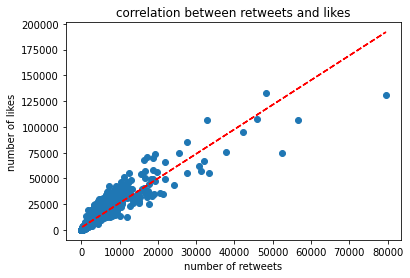

```python
import numpy as np
import matplotlib.pyplot as plt
x=df['retweet_count']
y=df['favorite_count']
plt.scatter(x  ,y)
z = np.polyfit(x, y, 1)
p = np.poly1d(z)
plt.plot(x,p(x),"r--")
plt.xlabel('number of retweets')
plt.ylabel('number of likes')
plt.title('correlation between retweets and likes')
```